# Mosaic plots

Maren Westermann

#### Note: the data frame ‘adult’ was provided by DataCamp

#### Load the knitr package

```r
library(knitr)
```

## Marimekko/Mosaic Plot

#### The initial contingency table

`DF <- as.data.frame.matrix(table(adult$SRAGE_P, adult$RBMI))`

#### Add the columns groupsSum, xmax and xmin. Remove groupSum again.

`DF$groupSum <- rowSums(DF)`  
`DF$xmax <- cumsum(DF$groupSum)`  
`DF$xmin <- DF$xmax - DF$groupSum`  
`# The groupSum column needs to be removed, don't remove this line` `DF$groupSum <- NULL`

#### Copy row names to variable X

`DF$X <- row.names(DF)`

#### Melt the dataset

`library(reshape2)`  
`DF_melted <- melt(DF, id.vars = c("X", "xmin", "xmax"), variable.name = "FILL")`

#### dplyr call to calculate ymin and ymax - don’t change

`library(dplyr)`  
`DF_melted <- DF_melted %>%`  
`group_by(X) %>%`  
`mutate(ymax = cumsum(value/sum(value)),`  
`ymin = ymax - value/sum(value))`

#### Plot rectangles - don’t change.

`library(ggthemes)`  
`ggplot(DF_melted, aes(ymin = ymin,`  
`ymax = ymax,`  
`xmin = xmin,`  
`xmax = xmax,`  
`fill = FILL)) +`  
`geom_rect(colour = "white") +`  
`scale_x_continuous(expand = c(0,0)) +`  
`scale_y_continuous(expand = c(0,0)) +`  
`BMI_fill +`  
`theme_tufte()`

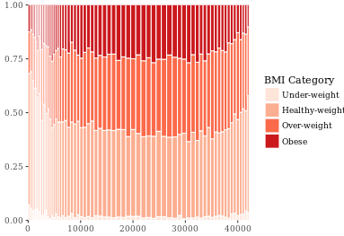

```r
include_graphics("images/marimekko_1.png")
```

## Adding statistics

#### Perform chi.sq test (RBMI and SRAGE_P)

`results <- chisq.test(table(adult$RBMI, adult$SRAGE_P))`

#### Melt `results$residuals` and store as resid

`resid <- melt(results$residuals)`

#### Change names of resid

`names(resid) <- c("FILL", "X", "residual")`

#### merge the two datasets:

`DF_all <- merge(DF_melted, resid)`

#### Update plot command

`library(ggthemes)`  
`ggplot(DF_all, aes(ymin = ymin,`  
`ymax = ymax,`  
`xmin = xmin,`  
`xmax = xmax,`  
`fill = residual)) +`  
`geom_rect() +`  
`scale_fill_gradient2() +`  
`scale_x_continuous(expand = c(0,0)) +`  
`scale_y_continuous(expand = c(0,0)) +`  
`theme_tufte()`

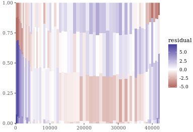

```r
include_graphics("images/adding_statistics_1.png")
```

## Adding text

#### Position for labels on x axis

`DF_all$xtext <- DF_all$xmin + (DF_all$xmax - DF_all$xmin)/2`

#### Position for labels on y axis (don’t change)

`index <- DF_all$xmax == max(DF_all$xmax)`  
`DF_all$ytext <- DF_all$ymin[index] + (DF_all$ymax[index] - DF_all$ymin[index])/2`

#### Plot

`ggplot(DF_all, aes(ymin = ymin, ymax = ymax, xmin = xmin,`  
`xmax = xmax, fill = residual)) +`  
`geom_rect(col = "white") +`  
`# geom_text for ages (i.e. the x axis)`  
`geom_text(aes(x = xtext,`  
`label = X),`  
`y = 1,`  
`size = 3,`  
`angle = 90,`  
`hjust = 1,`  
`show.legend = FALSE) +`  
`# geom_text for BMI (i.e. the fill axis)`  
`geom_text(aes(x = max(xmax),`  
`y = ytext,`  
`label = FILL),`  
`size = 3,`  
`hjust = 1,`  
`show.legend = FALSE) +`  
`scale_fill_gradient2() +`  
`theme_tufte() +`  
`theme(legend.position = "bottom")`

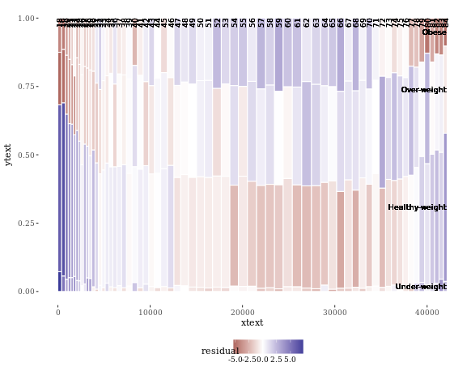

```r
include_graphics("images/adding_text_1.png")
```

## Generalizations

#### Load all packages

`library(ggplot2)`  
`library(reshape2)`  
`library(dplyr)`  
`library(ggthemes)`

#### Script generalized into a function

`mosaicGG <- function(data, X, FILL) {`  
`# Proportions in raw data`  
`DF <- as.data.frame.matrix(table(data[[X]], data[[FILL]]))`  
`DF$groupSum <- rowSums(DF)`  
`DF$xmax <- cumsum(DF$groupSum)`  
`DF$xmin <- DF$xmax - DF$groupSum`  
`DF$X <- row.names(DF)`  
`DF$groupSum <- NULL`  
`DF_melted <- melt(DF, id = c("X", "xmin", "xmax"), variable.name = "FILL")`  
`library(dplyr)`  
`DF_melted <- DF_melted %>%`  
`group_by(X) %>%`  
`mutate(ymax = cumsum(value/sum(value)),`  
`ymin = ymax - value/sum(value))`  
`# Chi-sq test`  
`results <- chisq.test(table(data[[FILL]], data[[X]])) #### fill and then x`  
`resid <- melt(results$residuals)`  
`names(resid) <- c("FILL", "X", "residual")`  
`# Merge data`  
`DF_all <- merge(DF_melted, resid)`  
`# Positions for labels`  
`DF_all$xtext <- DF_all$xmin + (DF_all$xmax - DF_all$xmin)/2`  
`index <- DF_all$xmax == max(DF_all$xmax)`  
`DF_all$ytext <- DF_all$ymin[index] + (DF_all$ymax[index] - DF_all$ymin[index])/2`  
`# plot:`  
`g <- ggplot(DF_all, aes(ymin = ymin, ymax = ymax, xmin = xmin,`  
`xmax = xmax, fill = residual)) +`  
`geom_rect(col = "white") +`  
`geom_text(aes(x = xtext, label = X),`  
`y = 1, size = 3, angle = 90, hjust = 1, show.legend = FALSE) +`  
`geom_text(aes(x = max(xmax), y = ytext, label = FILL),`  
`size = 3, hjust = 1, show.legend = FALSE) +`  
`scale_fill_gradient2("Residuals") +`  
`scale_x_continuous("Individuals", expand = c(0,0)) +`  
`scale_y_continuous("Proportion", expand = c(0,0)) +`  
`theme_tufte() +`  
`theme(legend.position = "bottom")`  
`print(g)`  
`}`

#### BMI described by age

`mosaicGG(adult, "SRAGE_P","RBMI")`

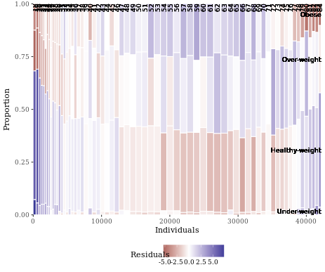

```r
include_graphics("images/generalizations_1.png")
```

#### Poverty described by age

`mosaicGG(adult, "SRAGE_P","POVLL")`

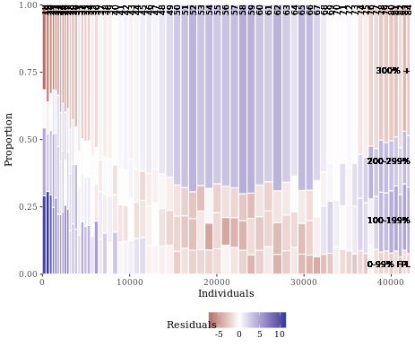

```r
include_graphics("images/generalizations_2.png")
```

#### mtcars: am described by cyl

`mosaicGG(mtcars, "cyl","am")`

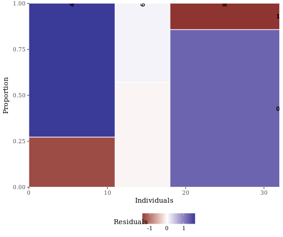

```r
include_graphics("images/generalizations_3.png")
```

#### Vocab: vocabulary described by education

`library(car)` `mosaicGG(Vocab, "education","vocabulary")`

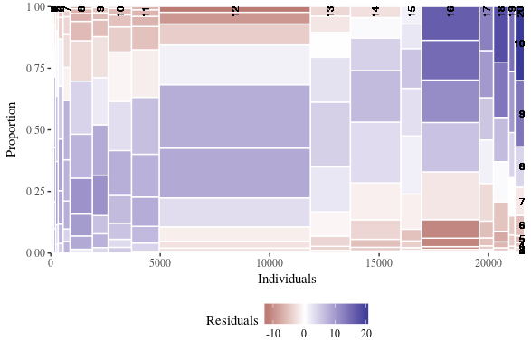

```r
include_graphics("images/generalizations_4.png")
```